# How to minimize mistakes

Good coding practices

Felix Schönbrodt

felix.schoenbrodt@psy.lmu.de

Ludwig-Maximilians-Universität München

Caroline Zygar-Hoffmann

caroline.zygar@psy.lmu.de

Ludwig-Maximilians-Universität München

2026-06-12

## The Ideal? Reality?

- Surrounded from a flood of fake news, science is one of (the last?) sources of credible information.
- Trust in science: Scientists are impartial, meticulous, and check their results rigorously in peer review before publication
- Although error-freeness cannot be guaranteed, science provides the most reliable source of information, and if errors happen, they soon get detected and corrected.
- Replication/credibility crisis
- Number of retractions rises exponentially
- Pressure to „publish or perish“ leads to hurried manuscript, less error checking
- Reviewer overload leads to superficial reviews
- AI tools create fake science that is hard to detect
- **statcheck** (Nuijten et al., 2016): 50% of psychology papers contain at least one inconsistent statistic

Where can errors happen during data collection or data analysis? Be creative!

## Mistakes lurk everywhere

- Errors in data collection software/scripts
- Error in manual data transcription
- Analyzing the wrong data set (e.g., an old version, a filter has been unknowingly applied)
- Coding errors
  - Wrong group assignment (control/ experimental group)
  - NAs coded as 99?
- Faulty analysis software; version changes in R packages
- Mistyping numbers when copying them from R to manuscript
- Send the wrong file to the journal submission system
- Asymmetry: Mistakes tend to go in the preferred direction (Gould, 1996), because we check more vigorously when results (unexpectedly) go into the wrong direction.
  - See also „garden of forking paths“ (Gelman & Loken, 2013): A lot of *p*-hacking is unintentional

## Mistakes lurk everywhere

### Examples: Miscoding Missing Values

- Jasso (1985): Coital frequency increases with wife’s age
  - Kahn/Udry (1986): 4 observations had value 88; Jasso treated these as valid values; treating these as missing, the effect of wife’s age becomes non-significant
- Herring (2009): Diversity increases firm revenue
  - Stojmenovska/Bol/Leopold (2017): 206 firms had values 88,888,888,888; Herring treated these as valid values; treating these as missing, the effect of diversity becomes non-significant
- Munsch (2015): Marital infidelity is at 10%
  - Munsch (2018): 246 missings were miscoded as “infidelity” (“Stata `.`-problem”); with correct coding marital infidelity is at 6%

Taken from a presentation from Katrin Auspurg & Josef Brüderl. All examples are from publications in the *American Sociological Review*, considered one of the very top journals in sociology.

## How to prevent coding errors?

[figure not shown]

https://www.osnews.com/story/19266/wtfsm/

## Unit tests / sanity checks

- **Always** look at the descriptive statistics (min, max, NAs, mean) of **every** variable (also transformed/computed variables)
  - Know the scales of your variables: Is the mean plausible? Is the minimum and maximum value theoretically possible and plausible?
  - Does a scale value from multiple items have only discrete values?
  - Do z-standardized variables really have *mean*=0 and *SD*=1?
- Plot all variables (scatterplot, histograms)

## Unit tests / sanity checks

The *summarytools* package makes this really easy:

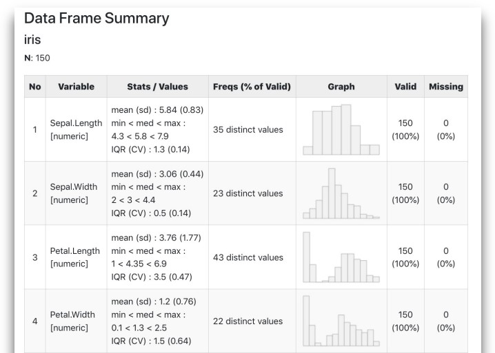

```r
library(summarytools)
view(dfSummary(data))
```

alternatively: `codebook` package by Ruben Arslan (also has an RStudio plugin). Has some nice convenience functions, e.g. when importing SPSS or other data files.

## Technical reproducibility

1. When you rely on random numbers (e.g., in simulation studies): Set a seed for reproducibility (e.g., `set.seed(123)`)
   - Take care when doing parallel computing, this sometimes requires special treatment of seeds
2. Document exact versions of all packages/ external programs at each completed stage of data analysis
   - e.g., in R: Save the `sessionInfo()` of the analytical pipeline in the README file when you submit a paper, and for every revision
3. Save a snapshot of the current version/state of the statistical software
   - e.g., in `R`: packages `renv`, `checkpoint`, or `packrat`
4. The safest way: Make a docker container which contains the full computational environment (including the OS)

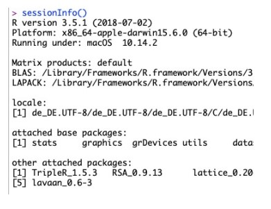

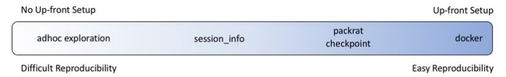

Graphic from https://rviews.rstudio.com/2018/01/18/package-management-for-reproducible-r-code/

## File name and path conventions

**Which is an example of a sensible file naming convention?**

- `final_FINAL_v3_new_final.docx`
- `2024-03-15_Projectname_Dataset_v01.csv`
- `Document1.docx`
- `data (copy).xlsx`

## File name and path conventions

- Use descriptive and consistent names for files and directories.
- For dates always use ISO dates: `YYYY-MM-DD`.
- Use paths relative to the project root instead of absolute paths:

- Set the project root as working directory in `R` by creating a `.Rproj` file in `C:/Users/felix/Empra_Project/`
- In scripts, only use relative paths: `read.csv("raw_data/study1.csv")`

## File organization

- (The following guidelines apply to many, but not all possible types of projects)
- All files that are necessary for reproducing the results should be bundled in one directory
  - Including: primary unprocessed data files, scripts for data preprocessing, cached intermediate data objects, scripts for hypothesis testing, generated result plots, …
  - Goal: You zip the directory, send it to somebody, and the person can reproduce the full analytical pipeline.
- Use a consistent, self-explanatory subdirectory structure
- Number script files in execution order (see next slide)

## Directory organization

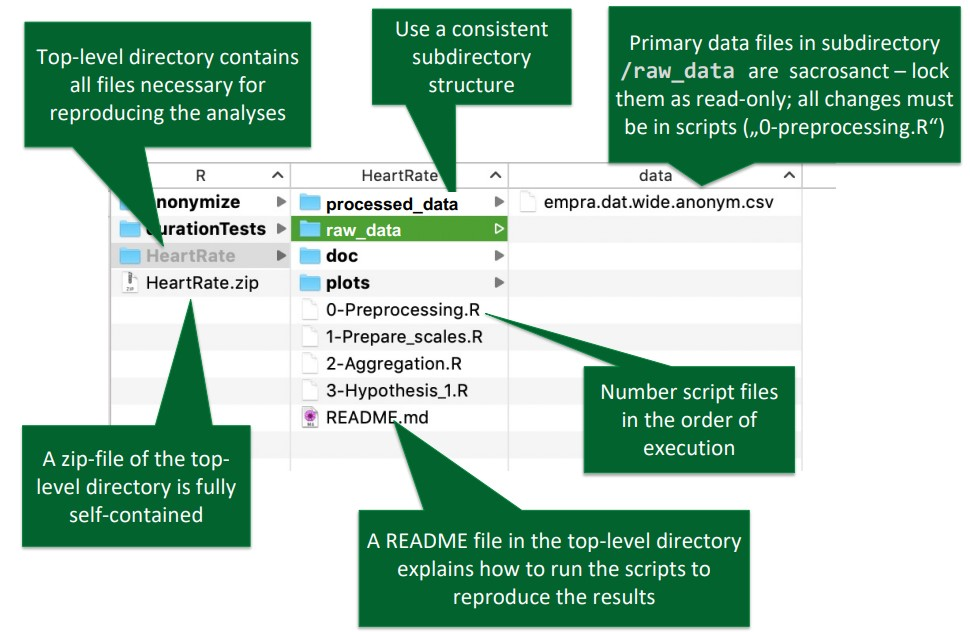

## Subdirectory organization

### The README file

- Nowadays, it is typically in markdown format (i.e., `README.md`) as it is rendered in Github and other repositories
- Located at the top level of the project directory, it is *the* central entry point for other users: What do they need to get started? How can you make their life easier?
- Consider to add the following information:
  - Project title, authors, date, contact information
  - Instructions on how to cite the project (or a link to an existing preprint or publication)
  - A brief description of the project
  - An overview of the directory structure
  - Instructions on how to reproduce the results
  - A license statement
- There might be additional READMEs in subfolders, explaining what is happening in that folder.

## Variable name conventions 1

- `snake_case`, `camelCase`, `PascalCase`, `dot.style`, `sTUdLy_cAPs`?
  - Do not use dots in variables (clashes with some functions)
  - Some consensus that snake_case is the best choice, but respect language specific coding conventions
  - Be consistent!
- Prefer short variable names (less typing while coding). But:  
  understandability >> brevity

```r
average_heart_rate
averageHeartRate
AverageHeartRate
average.heart.rate
aVErAgeHeARTraTe
```

```r
average_heart_rate
avg_heart_rate
avg_HR
aHR
var001
x
```

## Variable name conventions 2

- Before: Inconsistent mixture of naming styles

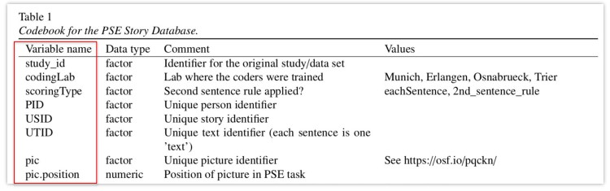

- After: Consistent naming style

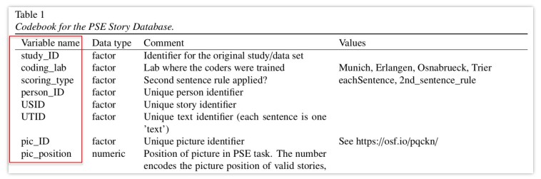

## Code commenting 1

- At the start of each script file: Author, license, purpose of the file.
- Load packages all at once at the beginning of the file
- Rule of thumb: At least 1 comment per 3 lines of code
- Separate chunks of code with comment lines
- Use English variable names and comments from the beginning (you don‘t want to translate everything before dissemination)

```r
## This source code is licensed under the FreeBSD License (see ...)
## (c) 2017 Felix Schönbrodt

## This file runs the Monte-Carlo simulations reported
## in Schönbrodt & Perugini (2013). doi:10.1016/j.jrp.2013.05.009

library(dplyr)
library(doParallel)

# Register multicore
nCore <- 10
registerDoParallel(cores=nCore)

# Load Ruscio's function for inducing a correlation into an
# existing empirical marginal distributions
source("00-Ruscio_GenData.R")

## Simulation parameters
popsize <- 1000000 # size of population from which samples are drawn
n.max <- 1000 # maximum sample size
```

## Code commenting 2

- Link code comments to paper structure
  - „Table 3: Descriptives of…“
  - „Hypothesis 2: Does metafilin increase […]?“
- Bonus: Link code comments to IDs of the preregistration
- If the file gets too long (e.g., > 500 lines), split into multiple files
- Literate Programming (Donald Knuth, developer of $\LaTeX$): Computer code is for humans, not just for computers.

## Collaboration

- Pair Programming
  - “Pair programming is an agile software development technique in which two programmers work together at one workstation. One, the **driver**, writes code while the other, the **observer** or **navigator**, reviews each line of code as it is typed in. The two programmers switch roles frequently.” ([Wikipedia](https://en.wikipedia.org/wiki/Pair_programming))
  - Nowadays, often an AI agent is the driver, while the human is an unskilled observer who has no idea what the code is actually doing.
- Golden route for increasing trust in code quality: Independent implementation (but nearly never done).

## References

- Upcoming: Roggenkamp et al. (2026): Promoting the computational reproducibility of the social and behavioral sciences
- Bishop, D. V. M. (2018). Fallibility in Science: Responding to Errors in the Work of Oneself and Others. Advances in Methods and Practices in Psychological Science, 1(3), 432–438. http://doi.org/10.1177/2515245918776632
- Rouder, J. N., Haaf, J. M., & Snyder, H. K. (2019). Minimizing Mistakes in Psychological Science. Advances in Methods and Practices in Psychological Science, 2(1), 3–11. https://doi.org/10.1177/2515245918801915
- Strand, J. F. (2025). Error tight: Exercises for lab groups to prevent research mistakes. Psychological Methods, 30(2), 416–424. https://doi.org/10.1037/met0000547
- Karthik Ram: How To Make Your Data Analysis Notebooks More Reproducible
  - https://github.com/karthik/rstudio2019
  - https://inundata.org/talks/rstd19/#/

# End

## Contact

- [@nicebread@scicomm.xyz](https://scicomm.xyz/@nicebread)
- ed.uml.ysp@tdorbneohcs.xilef
- https://www.nicebread.de
- https://github.com/nicebread